# Profit Optimization

Causal Decision Analysis under a Capacity Constraint

Andrej Arpáš

12/15/2020

# Problem Setup

Imagine you’re optimizing (maximizing) for profit of some small business. The business has corporate clients and you must decide whom to target in a marketing campaign. Contact is a phone call; the call center can handle at most one quarter of the client base. The pilot is a **randomized** contact experiment: `treatment = 1` means contacted. `purchase` is the observed outcome. Features $X = (V_1,\ldots,V_{20})$ are anonymized.

Contact costs 5; a purchase yields incremental discounted CLV of 100. Potential outcomes $(Y(0), Y(1))$ are not both observed. Because the pilot randomizes contact, the conditional average treatment effect (CATE)

$$\tau(x) \;=\; \mathbb{E}[Y(1)-Y(0)\mid X=x]$$

is identified by

$$\tau(x) \;=\; \mathbb{E}[Y\mid T=1,X=x] - \mathbb{E}[Y\mid T=0,X=x].$$

Decision-relevant expected incremental profit is

$$\mathrm{EV}(x) \;=\; 100\,\tau(x) - 5.$$

Under a hard capacity $\sum_i d_i \le \lfloor N/4\rfloor$, the Bayes-optimal rule (linear utility, known costs) ranks customers by posterior expected $\mathrm{EV}(x)$ and contacts the highest-scoring clients, never exceeding capacity and never contacting a client whose posterior mean $\mathrm{EV}$ is negative.

Purchase prediction at a fixed 0.5 threshold is a natural baseline, but the operational objective is expected incremental profit under that capacity constraint. The analysis therefore fits ensemble classifiers on the treated pilot arm, then centers the recommendation on a **joint Bayesian logistic S-learner with treatment interactions**, with held-out **IPW policy-value** checks and a Bayesian T-learner sensitivity comparison. The recommendation is a single binary `decision` per row of the customer base (row order preserved), written to `decisions_recommended.csv`.

## Data

Two input tables ship in `data/` (original challenge filenames preserved):

| File | Role |
| --- | --- |
| `pilot.csv` | Randomized contact experiment: features $V_1$–$V_{20}$, `treatment`, `purchase` |
| `CustomerBase.csv` | Full client list to score: features $V_1$–$V_{20}$ only |

The output recommendation is `decisions_recommended.csv` at the project root (one column, `decision` ∈ $\{0,1\}$, one row per `CustomerBase.csv` row).

```r
pilot <- readr::read_csv(file.path(data_dir, "pilot.csv"), show_col_types = FALSE) |>
  mutate(
    across(c(V2, V19), as.factor),
    treatment = as.integer(treatment),
    purchase = as.integer(purchase)
  )

customer_base <- readr::read_csv(
  file.path(data_dir, "CustomerBase.csv"),
  show_col_types = FALSE
) |>
  mutate(across(c(V2, V19), as.factor))

for (col in c("V2", "V19")) {
  customer_base[[col]] <- factor(
    as.character(customer_base[[col]]),
    levels = levels(pilot[[col]])
  )
}

n_base <- nrow(customer_base)
call_capacity <- floor(capacity_frac * n_base)
propensity <- mean(pilot$treatment) # known design propensity (≈ RCT rate)

pilot |>
  filter(treatment == 1) |>
  head() |>
  as_tibble()
```

```
# A tibble: 6 × 22
     V1 V2       V3    V4    V5    V6    V7    V8    V9   V10   V11    V12   V13
  <dbl> <fct> <dbl> <dbl> <dbl> <dbl> <dbl> <dbl> <dbl> <dbl> <dbl>  <dbl> <dbl>
1  0.76 A      0.11  0.44 36.7   0.28  47.0  0.38  1.67  5.5     18   27.8  0.68
2  1.09 A      0.42  0.16  2.04  0.37  36.7  0.49  0.7   9.27    10   31.4  0.51
3  0.69 A      0.24  0.87  6.02  0.3   44.0  0.56  2.39  9.47    19   48.2  0.68
4  0.98 A      0.62  0.93 31.2   1.83  44.8  0.81  4.51  8.1     19  704.   0.67
5  0.68 A      0.75  0.18 62.6   0.42  40.0  0.25  2.13  7.78    14   33.0  0.64
6  4.85 A      0.78  0.64 18.2   0.75  50.1  0.53  0.6  13.8     13 1730.   0.05
# ℹ 9 more variables: V14 <dbl>, V15 <dbl>, V16 <dbl>, V17 <dbl>, V18 <dbl>,
#   V19 <fct>, V20 <dbl>, treatment <int>, purchase <int>
```

```r
pilot |>
  group_by(treatment) |>
  summarise(
    n = n(),
    purchases = sum(purchase),
    purchase_rate = mean(purchase),
    .groups = "drop"
  )
```

```
# A tibble: 2 × 4
  treatment     n purchases purchase_rate
      <int> <int>     <int>         <dbl>
1         0  4003       315        0.0787
2         1   997       102        0.102
```

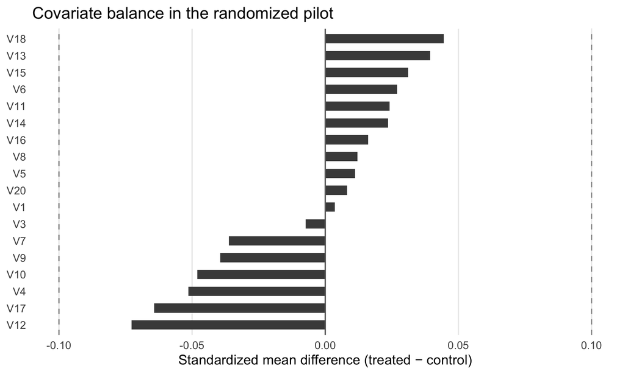

```r
# Covariate balance (standardized mean differences), as a randomization check.
num_x <- pilot |>
  select(where(is.numeric), -treatment, -purchase) |>
  names()

balance <- map_dfr(num_x, function(v) {
  x1 <- pilot[[v]][pilot$treatment == 1]
  x0 <- pilot[[v]][pilot$treatment == 0]
  m1 <- mean(x1, na.rm = TRUE)
  m0 <- mean(x0, na.rm = TRUE)
  s <- sd(pilot[[v]], na.rm = TRUE)
  tibble(variable = v, smd = (m1 - m0) / s)
})

balance |>
  ggplot(aes(smd, reorder(variable, smd))) +
  geom_col(width = 0.55, fill = "#4a4a4a", colour = NA) +
  geom_vline(xintercept = 0, colour = "grey40") +
  geom_vline(xintercept = c(-0.1, 0.1), linetype = "dashed", colour = "grey60") +
  labs(
    x = "Standardized mean difference (treated − control)",
    y = NULL,
    title = "Covariate balance in the randomized pilot"
  ) +
  theme_minimal(base_size = 11) +
  theme(panel.grid.minor = element_blank(), panel.grid.major.y = element_blank())
```

Balance SMDs near zero support treating the pilot as a credible RCT for identifying $\tau(x)$.

```r
set.seed(42)
# Held-out pilot fold for policy evaluation (not used to fit the deployment model).
pilot_split <- initial_split(pilot, prop = 0.7, strata = purchase)
pilot_train <- training(pilot_split)
pilot_eval <- testing(pilot_split)

treated_train <- pilot_train |> filter(treatment == 1)
```

## EDA (brief)

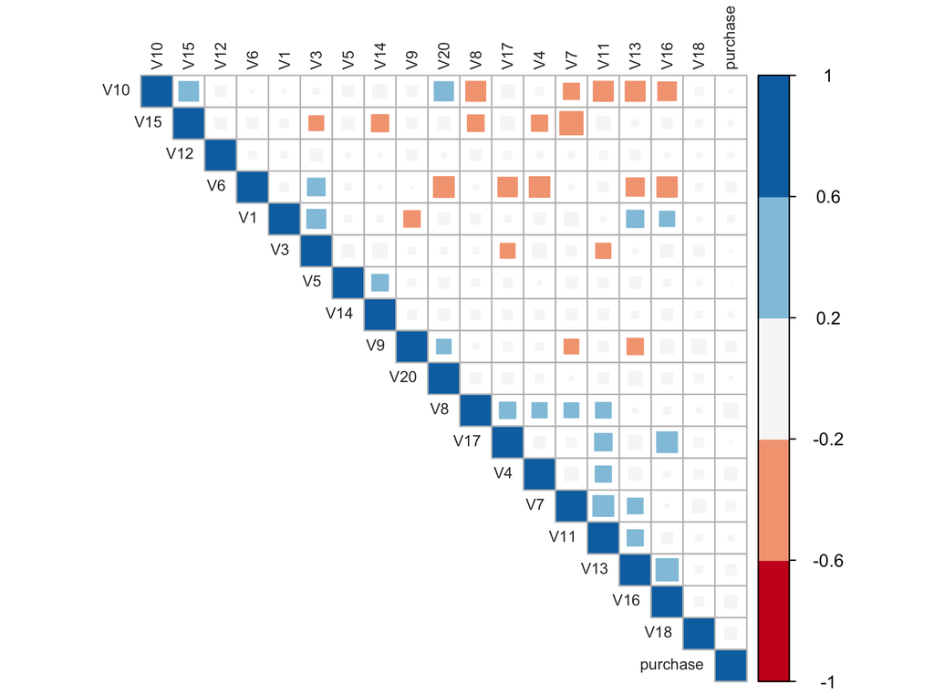

```r
corr <- cor(
  pilot |> select(where(is.numeric), -treatment),
  use = "pairwise.complete.obs"
)
corrplot(
  round(corr, 3),
  method = "square",
  type = "upper",
  tl.col = "grey20",
  tl.cex = 0.7,
  order = "hclust",
  col = brewer.pal(n = 5, name = "RdBu"),
  cl.ratio = 0.2
)
```

# Baseline: supervised purchase classifiers

```r
set.seed(42)
e <- treated_train |>
  select(-treatment) |>
  mutate(buybool = factor(purchase, levels = c(0, 1), labels = c("no", "yes"))) |>
  select(-purchase)

split_e <- initial_split(e, prop = 0.75, strata = buybool)
e_train <- training(split_e)
e_test <- testing(split_e)

rec <- recipe(buybool ~ ., data = e_train) |>
  step_dummy(all_nominal_predictors()) |>
  step_zv(all_predictors()) |>
  step_normalize(all_numeric_predictors())

rf_fit <- workflow() |>
  add_recipe(rec) |>
  add_model(
    rand_forest(trees = 600) |>
      set_engine("randomForest", importance = TRUE) |>
      set_mode("classification")
  ) |>
  fit(e_train)

bind_cols(purchase = e_test$buybool, predict(rf_fit, new_data = e_test)) |>
  conf_mat(truth = purchase, estimate = .pred_class)
```

```
          Truth
Prediction  no yes
       no  168  10
       yes   0   0
```

[figure not shown]

```r
rf_imp <- vip::vi(extract_fit_engine(rf_fit)) |>
  as_tibble() |>
  transmute(variable = Variable, importance = Importance) |>
  slice_max(importance, n = 10)
plot_importance(rf_imp, colour = col_pastel_terra)
```

```r
boost_fit <- workflow() |>
  add_recipe(rec) |>
  add_model(
    boost_tree(trees = 300, learn_rate = 0.05, tree_depth = 3) |>
      set_engine("xgboost") |>
      set_mode("classification")
  ) |>
  fit(e_train)

bind_cols(purchase = e_test$buybool, predict(boost_fit, new_data = e_test)) |>
  conf_mat(truth = purchase, estimate = .pred_class)
```

```
          Truth
Prediction  no yes
       no  164   8
       yes   4   2
```

[figure not shown]

```r
boost_imp <- vip::vi(extract_fit_engine(boost_fit)) |>
  as_tibble() |>
  transmute(variable = Variable, importance = Importance) |>
  slice_max(importance, n = 10)
plot_importance(boost_imp, colour = col_pastel_blue)
```

As expected under imbalance, 0.5-threshold ensembles are poor campaign rules. Importance plots are exploratory only.

# Primary model: joint Bayesian S-learner

Let $X$ be the numeric feature set used for causal modeling (dropping sparse categoricals that fracture cells). Fit on `pilot_train`:

$$\mathrm{logit}\,\mathbb{E}[Y\mid T,X]
= \alpha + X^\top\beta + T\,\gamma + T\,X^\top\delta.$$

```r
feature_cols <- c(
  "V1", "V3", "V4", "V5", "V6", "V7", "V8", "V9", "V10", "V11",
  "V12", "V13", "V14", "V15", "V16", "V17", "V18", "V20"
)

make_model_frame <- function(df) {
  df |>
    select(purchase, treatment, all_of(feature_cols)) |>
    mutate(across(all_of(feature_cols), as.numeric))
}

train_j <- make_model_frame(pilot_train)
eval_j <- make_model_frame(pilot_eval)
base_j <- customer_base |>
  transmute(treatment = 0L, across(all_of(feature_cols), as.numeric))

# Center features using training means (shared for T=0/1 counterfactuals).
x_means <- colMeans(train_j[, feature_cols])
center_x <- function(df) {
  df |>
    mutate(across(all_of(feature_cols), \(z) z - x_means[cur_column()]))
}
train_j <- center_x(train_j)
eval_j <- center_x(eval_j)
base_j <- center_x(base_j)

form_s <- as.formula(
  paste(
    "purchase ~ treatment +",
    paste(feature_cols, collapse = " + "),
    "+",
    paste0("treatment:(", paste(feature_cols, collapse = " + "), ")")
  )
)
form_s
```

```
purchase ~ treatment + V1 + V3 + V4 + V5 + V6 + V7 + V8 + V9 +
    V10 + V11 + V12 + V13 + V14 + V15 + V16 + V17 + V18 + V20 +
    treatment:(V1 + V3 + V4 + V5 + V6 + V7 + V8 + V9 + V10 +
        V11 + V12 + V13 + V14 + V15 + V16 + V17 + V18 + V20)
```

```r
# rstanarm::stan_glm (2.32) has no separate prior_interaction argument.
# Moderately regularizing Student-t on all slopes (main + treatment x feature);
# QR reparameterization improves geometry with correlated covariates.
t_prior <- student_t(df = 7, location = 0, scale = 1.5)
t_prior_intcpt <- student_t(df = 7, location = 0, scale = 2.5)

fit_s <- stan_glm(
  form_s,
  data = train_j,
  family = binomial(link = "logit"),
  prior = t_prior,
  prior_intercept = t_prior_intcpt,
  QR = TRUE,
  chains = 4,
  iter = 2000,
  warmup = 1000,
  cores = 4,
  refresh = 0,
  seed = 42
)
```

```r
print(summary(fit_s, probs = c(0.05, 0.95)), digits = 2)
```

```
Model Info:
 function:     stan_glm
 family:       binomial [logit]
 formula:      purchase ~ treatment + V1 + V3 + V4 + V5 + V6 + V7 + V8 + V9 +
       V10 + V11 + V12 + V13 + V14 + V15 + V16 + V17 + V18 + V20 +
       treatment:(V1 + V3 + V4 + V5 + V6 + V7 + V8 + V9 + V10 +
       V11 + V12 + V13 + V14 + V15 + V16 + V17 + V18 + V20)
 algorithm:    sampling
 sample:       4000 (posterior sample size)
 priors:       see help('prior_summary')
 observations: 3500
 predictors:   38

Estimates:
                mean   sd    5%    95%
(Intercept)   -3.59   0.14 -3.82 -3.36
treatment      0.08   0.30 -0.44  0.57
V1             0.10   0.05  0.02  0.18
V3             0.81   0.35  0.23  1.39
V4             3.28   0.38  2.68  3.90
V5             0.00   0.00  0.00  0.00
V6            -0.25   0.11 -0.42 -0.07
V7            -0.10   0.03 -0.14 -0.06
V8            -3.42   0.38 -4.05 -2.80
V9             0.18   0.04  0.12  0.25
V10            0.02   0.04 -0.05  0.09
V11            0.06   0.03  0.01  0.11
V12            0.00   0.00  0.00  0.00
V13            1.18   0.46  0.44  1.93
V14            0.00   0.00 -0.01  0.00
V15           -0.01   0.04 -0.08  0.06
V16            2.38   0.46  1.63  3.14
V17           -0.08   0.05 -0.16  0.00
V18            0.55   0.32  0.01  1.07
V20           -0.06   0.02 -0.09 -0.03
treatment:V1   0.11   0.13 -0.10  0.33
treatment:V3   0.30   0.84 -1.08  1.67
treatment:V4   0.47   0.83 -0.87  1.85
treatment:V5   0.00   0.00  0.00  0.00
treatment:V6   0.08   0.21 -0.27  0.41
```

[output cut: 49 more lines]

```
treatment:V9  0.00 1.00 5747
treatment:V10 0.00 1.00 5627
treatment:V11 0.00 1.00 5684
treatment:V12 0.00 1.00 5808
treatment:V13 0.01 1.00 6474
treatment:V14 0.00 1.00 1965
treatment:V15 0.00 1.00 5627
treatment:V16 0.01 1.00 4430
treatment:V17 0.00 1.00 5327
treatment:V18 0.01 1.00 5464
treatment:V20 0.00 1.00 4849
mean_PPD      0.00 1.00 4583
log-posterior 0.12 1.00 1546

For each parameter, mcse is Monte Carlo standard error, n_eff is a crude measure of effective sample size, and Rhat is the potential scale reduction factor on split chains (at convergence Rhat=1).
```

```r
rh <- rhat(fit_s)
ne <- neff_ratio(fit_s)
tibble(
  max_rhat = max(rh, na.rm = TRUE),
  min_neff_ratio = min(ne, na.rm = TRUE),
  n_pars = length(rh)
)
```

```
# A tibble: 1 × 3
  max_rhat min_neff_ratio n_pars
     <dbl>          <dbl>  <int>
1     1.00          0.491     38
```

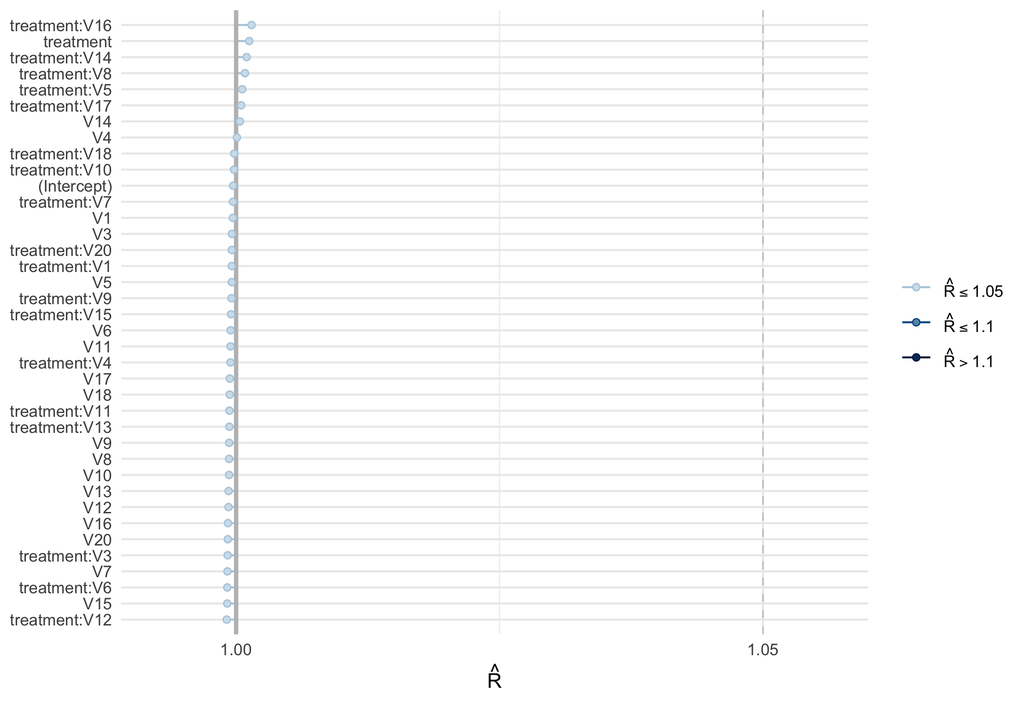

```r
mcmc_rhat(rh) + yaxis_text(hjust = 1) + theme_minimal(base_size = 10)
```

```r
loo_s <- loo(fit_s, save_psis = TRUE, k_threshold = 0.7)
print(loo_s)
```

```
Computed from 4000 by 3500 log-likelihood matrix.

         Estimate   SE
elpd_loo   -772.7 34.4
p_loo        44.4  5.3
looic      1545.4 68.8
------
MCSE of elpd_loo is 0.2.
MCSE and ESS estimates assume independent draws (r_eff=1).

All Pareto k estimates are good (k < 0.7).
See help('pareto-k-diagnostic') for details.
```

# Posterior predictive checks

Check that the S-learner can regenerate the pilot’s purchase margins (overall and by arm). Replicated data $Y^{\mathrm{rep}}$ are drawn from the posterior predictive; observed summaries should land inside the bulk of the replicated distribution.

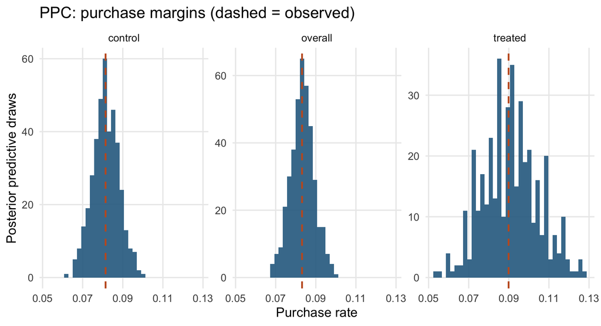

```r
y_obs <- train_j$purchase
t_obs <- train_j$treatment
yrep <- posterior_predict(fit_s, draws = 400)

ppc_stat <- function(y, group = NULL) {
  if (is.null(group)) {
    mean(y)
  } else {
    c(control = mean(y[group == 0]), treated = mean(y[group == 1]))
  }
}

obs_overall <- mean(y_obs)
rep_overall <- apply(yrep, 1, mean)
obs_by_arm <- ppc_stat(y_obs, t_obs)
rep_by_arm <- apply(yrep, 1, ppc_stat, group = t_obs)

ppc_tbl <- tibble(
  draw = seq_len(nrow(yrep)),
  overall = rep_overall,
  control = rep_by_arm[1, ],
  treated = rep_by_arm[2, ]
) |>
  pivot_longer(-draw, names_to = "margin", values_to = "rate")

obs_tbl <- tibble(
  margin = c("overall", "control", "treated"),
  rate = c(obs_overall, obs_by_arm["control"], obs_by_arm["treated"])
)

ggplot(ppc_tbl, aes(rate)) +
  geom_histogram(bins = 36, fill = "#2b6a8f", colour = NA, alpha = 0.9) +
  geom_vline(
    data = obs_tbl,
    aes(xintercept = rate),
    linetype = "dashed",
    colour = "#c45c26",
    linewidth = 0.7
  ) +
  facet_wrap(~margin, scales = "free_y", nrow = 1) +
  labs(
    x = "Purchase rate",
    y = "Posterior predictive draws",
    title = "PPC: purchase margins (dashed = observed)"
  ) +
  theme_minimal(base_size = 11) +
  theme(panel.grid.minor = element_blank())
```

```r
# Bayesian p-values: fraction of replicates at least as extreme as observed
# (two-sided via absolute deviation from the predictive mean).
bayes_p <- function(rep_vec, obs) {
  m <- mean(rep_vec)
  mean(abs(rep_vec - m) >= abs(obs - m))
}
tibble(
  margin = c("overall", "control", "treated"),
  observed = c(obs_overall, obs_by_arm["control"], obs_by_arm["treated"]),
  pred_mean = c(mean(rep_overall), mean(rep_by_arm[1, ]), mean(rep_by_arm[2, ])),
  bayes_p = c(
    bayes_p(rep_overall, obs_overall),
    bayes_p(rep_by_arm[1, ], obs_by_arm["control"]),
    bayes_p(rep_by_arm[2, ], obs_by_arm["treated"])
  )
)
```

```
# A tibble: 3 × 4
  margin  observed pred_mean bayes_p
  <chr>      <dbl>     <dbl>   <dbl>
1 overall   0.0831    0.0833   0.975
2 control   0.0814    0.0814   1
3 treated   0.0899    0.0909   0.95
```

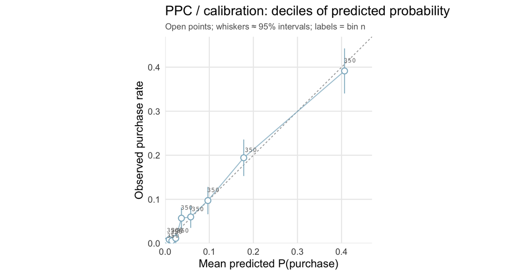

```r
# Mean calibration on the training fold: bin by posterior predictive mean.
p_hat_train <- colMeans(posterior_epred(fit_s, draws = 400))
cal_tbl <- tibble(p_hat = p_hat_train, y = y_obs) |>
  mutate(bin = ntile(p_hat, 10)) |>
  group_by(bin) |>
  summarise(
    n = n(),
    p_hat_mean = mean(p_hat),
    y_rate = mean(y),
    .groups = "drop"
  ) |>
  mutate(
    se = sqrt(pmax(y_rate * (1 - y_rate) / n, 1e-12)),
    lo = pmax(0, y_rate - 1.96 * se),
    hi = pmin(1, y_rate + 1.96 * se),
    # Stagger n labels so low-p deciles do not collide.
    lab_x = p_hat_mean + 0.012 + 0.004 * (bin %% 2),
    lab_y = y_rate + 0.018 + 0.006 * ((bin + 1) %% 2)
  )

cal_lim <- max(cal_tbl$p_hat_mean, cal_tbl$hi, cal_tbl$lab_x, cal_tbl$lab_y) * 1.06
ggplot(cal_tbl, aes(p_hat_mean, y_rate)) +
  geom_abline(
    slope = 1, intercept = 0, linetype = "22",
    colour = "grey65", linewidth = 0.4
  ) +
  geom_linerange(
    aes(ymin = lo, ymax = hi),
    colour = col_pastel_blue, linewidth = 0.45, alpha = 0.9
  ) +
  geom_line(colour = col_pastel_blue, linewidth = 0.45, alpha = 0.75) +
  geom_point(
    shape = 21, fill = "white", colour = col_pastel_blue,
    size = 2.3, stroke = 0.7
  ) +
  geom_text(
    aes(x = lab_x, y = lab_y, label = n),
    size = 2.4, colour = "grey45", family = "mono"
  ) +
  coord_equal(xlim = c(0, cal_lim), ylim = c(0, cal_lim), expand = FALSE) +
  labs(
    x = "Mean predicted P(purchase)",
    y = "Observed purchase rate",
    title = "PPC / calibration: deciles of predicted probability",
    subtitle = "Open points; whiskers ≈ 95% intervals; labels = bin n"
  ) +
  theme_minimal(base_size = 11) +
  theme(
    panel.grid.minor = element_blank(),
    plot.subtitle = element_text(size = 8.5, colour = "grey40")
  )
```

```r
# Counterfactual predictions on the held-out pilot fold.
nd1 <- eval_j |> mutate(treatment = 1L)
nd0 <- eval_j |> mutate(treatment = 0L)
p1_eval <- posterior_epred(fit_s, newdata = nd1, draws = 1000)
p0_eval <- posterior_epred(fit_s, newdata = nd0, draws = 1000)
ev_eval <- summarize_ev(p1_eval, p0_eval)

# Discrimination of uplift for realized treatment effect proxy among treated/control
# is subtle; report AUCs for each response surface instead.
auc_t1 <- auc(roc(eval_j$purchase[eval_j$treatment == 1],
                  colMeans(p1_eval)[eval_j$treatment == 1], quiet = TRUE))
auc_t0 <- auc(roc(eval_j$purchase[eval_j$treatment == 0],
                  colMeans(p0_eval)[eval_j$treatment == 0], quiet = TRUE))
tibble(auc_response_treated = as.numeric(auc_t1),
       auc_response_control = as.numeric(auc_t0))
```

```
# A tibble: 1 × 2
  auc_response_treated auc_response_control
                 <dbl>                <dbl>
1                0.732                0.835
```

# Sensitivity: Bayesian T-learner

Separate arms as a cross-check (independent priors; no shared residual structure).

```r
fit_t1 <- stan_glm(
  purchase ~ .,
  data = train_j |> filter(treatment == 1) |> select(-treatment),
  family = binomial(),
  prior = t_prior,
  prior_intercept = t_prior,
  QR = TRUE,
  chains = 4,
  iter = 2000,
  refresh = 0,
  seed = 42
)
fit_t0 <- stan_glm(
  purchase ~ .,
  data = train_j |> filter(treatment == 0) |> select(-treatment),
  family = binomial(),
  prior = t_prior,
  prior_intercept = t_prior,
  QR = TRUE,
  chains = 4,
  iter = 2000,
  refresh = 0,
  seed = 43
)

p1_t <- posterior_epred(
  fit_t1,
  newdata = eval_j |> select(-treatment, -purchase),
  draws = 1000
)
p0_t <- posterior_epred(
  fit_t0,
  newdata = eval_j |> select(-treatment, -purchase),
  draws = 1000
)
ev_t <- summarize_ev(p1_t, p0_t)

tibble(
  corr_uplift_s_vs_t = cor(ev_eval$uplift_mean, ev_t$uplift_mean),
  corr_ev_s_vs_t = cor(ev_eval$ev_mean, ev_t$ev_mean),
  mean_abs_ev_diff = mean(abs(ev_eval$ev_mean - ev_t$ev_mean))
)
```

```
# A tibble: 1 × 3
  corr_uplift_s_vs_t corr_ev_s_vs_t mean_abs_ev_diff
               <dbl>          <dbl>            <dbl>
1              0.999          0.999            0.245
```

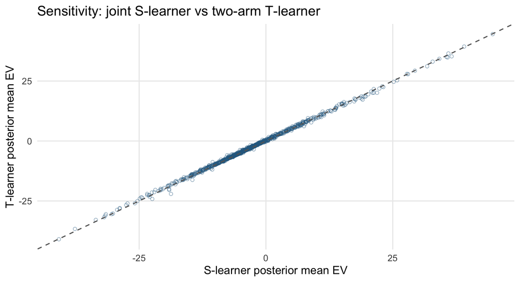

```r
tibble(s = ev_eval$ev_mean, t_learner = ev_t$ev_mean) |>
  ggplot(aes(s, t_learner)) +
  geom_point(
    shape = 21,
    fill = NA,
    colour = "#2b6a8f",
    alpha = 0.55,
    size = 1.35,
    stroke = 0.35
  ) +
  geom_abline(slope = 1, intercept = 0, linetype = "dashed", colour = "grey40") +
  labs(
    x = "S-learner posterior mean EV",
    y = "T-learner posterior mean EV",
    title = "Sensitivity: joint S-learner vs two-arm T-learner"
  ) +
  theme_minimal(base_size = 11) +
  theme(panel.grid.minor = element_blank())
```

# Held-out policy evaluation (IPW)

On `pilot_eval`, compare:

1. **Bayes EV policy** — rank by S-learner $\widehat{\mathrm{EV}}$, take top $k=\lfloor 0.25 n_{\mathrm{eval}}\rfloor$ among those with $\widehat{\mathrm{EV}}>0$ (else fill by EV).
2. **Propensity-of-purchase (treated arm only)** — rank by $\hat P(Y\mid T=1,X)$, same $k$.
3. **Random $k$** — mean over draws of random capacity fills.

Because $T$ is randomized with known propensity $e$, IPW is unbiased for $V(\pi)$ under standard positivity (here $e\in(0,1)$ by design).

```r
n_eval <- nrow(eval_j)
k_eval <- floor(capacity_frac * n_eval)

make_policy <- function(score, k, positive_only = TRUE) {
  ord <- order(score, decreasing = TRUE)
  pi <- rep(0, length(score))
  if (positive_only) {
    cand <- ord[score[ord] > 0]
    take <- head(cand, k)
    if (length(take) == 0) take <- head(ord, k)
  } else {
    take <- head(ord, k)
  }
  pi[take] <- 1
  pi
}

pi_bayes <- make_policy(ev_eval$ev_mean, k_eval, positive_only = TRUE)
pi_p1 <- make_policy(colMeans(p1_eval), k_eval, positive_only = FALSE)

set.seed(42)
v_random <- replicate(200, {
  pi_r <- rep(0, n_eval)
  pi_r[sample.int(n_eval, k_eval)] <- 1
  ipw_policy_value(eval_j$purchase, eval_j$treatment, pi_r, e = propensity)
})

policy_tbl <- tibble(
  policy = c("Bayes EV (S-learner)", "Treated-arm propensity", "Random capacity (mean)"),
  ipw_value = c(
    ipw_policy_value(eval_j$purchase, eval_j$treatment, pi_bayes, e = propensity),
    ipw_policy_value(eval_j$purchase, eval_j$treatment, pi_p1, e = propensity),
    mean(v_random)
  ),
  n_targeted = c(sum(pi_bayes), sum(pi_p1), k_eval)
) |>
  mutate(
    approx_profit_per_customer =
      clv_gain * ipw_value - contact_cost * (n_targeted / n_eval)
  )

knitr::kable(
  policy_tbl,
  digits = 4,
  caption = "Held-out IPW policy comparison on the pilot eval fold"
)
```

Held-out IPW policy comparison on the pilot eval fold

| policy | ipw_value | n_targeted | approx_profit_per_customer |
| --- | --- | --- | --- |
| Bayes EV (S-learner) | 0.1076 | 249 | 9.9332 |
| Treated-arm propensity | 0.0894 | 375 | 7.6863 |
| Random capacity (mean) | 0.0865 | 375 | 7.3971 |

[figure not shown]

```r
policy_tbl |>
  ggplot(aes(ipw_value, reorder(policy, ipw_value))) +
  hatched_col(
    width = 0.07,
    colour = col_pastel_blue,
    linewidth = 0.18,
    pattern_linewidth = 0.12,
    pattern_spacing = 0.045,
    pattern_density = 0.3
  ) +
  labs(
    x = "IPW estimate of E[Y under policy] on held-out pilot",
    y = NULL,
    title = "Policy value comparison (higher is better)"
  ) +
  plot_theme_bars(base_size = 10, axis_text_size = 8)
```

# Capacity–profit curve

Sweep contact budgets $k = 0,\ldots,\lfloor 0.40\,n_{\mathrm{eval}}\rfloor$ on the held-out fold. For each $k$, contact the top-$k$ customers by S-learner $\widehat{\mathrm{EV}}$ (no hard positivity cutoff — the curve itself shows where incremental EV turns negative). Report:

- **Model-based** expected incremental profit: $\sum_{i\in\mathrm{top}\text{-}k}\widehat{\mathrm{EV}}(x_i)$.
- **IPW** approximate profit per customer: $\mathrm{CLV}\cdot\hat V_{\mathrm{IPW}}(\pi_k) - c\cdot(k/n)$, with a bootstrap percentile band for the IPW curve.

The vertical line marks the business capacity $k=\lfloor N/4\rfloor$ on this fold.

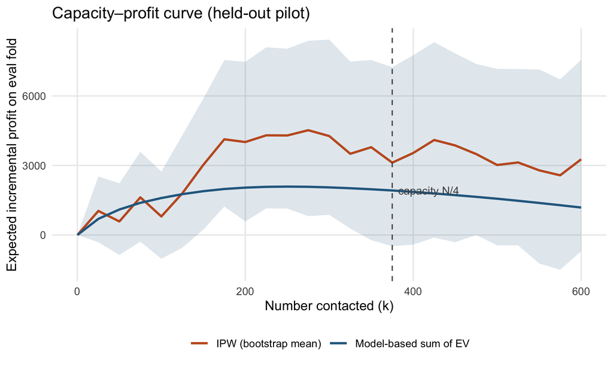

```r
score_ev <- ev_eval$ev_mean
ord_ev <- order(score_ev, decreasing = TRUE)
k_grid <- seq(0L, floor(0.40 * n_eval), by = 25L)
if (tail(k_grid, 1) != floor(0.40 * n_eval)) {
  k_grid <- c(k_grid, floor(0.40 * n_eval))
}

# Model-based cumulative EV along the ranked list.
cum_ev <- c(0, cumsum(score_ev[ord_ev]))

# Incremental IPW profit vs never-contact: CLV*(V(π_k)-V(0)) - c*(k/n).
boot_ipw_profit <- function(k, B = 300L) {
  if (k == 0L) {
    return(tibble(ipw_profit = 0, lo = 0, hi = 0))
  }
  pi <- rep(0, n_eval)
  pi[ord_ev[seq_len(k)]] <- 1
  pi0 <- rep(0, n_eval)
  set.seed(42 + k)
  boots <- replicate(B, {
    idx <- sample.int(n_eval, replace = TRUE)
    e_b <- mean(eval_j$treatment[idx])
    v_k <- ipw_policy_value(
      eval_j$purchase[idx],
      eval_j$treatment[idx],
      pi[idx],
      e = e_b
    )
    v_0 <- ipw_policy_value(
      eval_j$purchase[idx],
      eval_j$treatment[idx],
      pi0[idx],
      e = e_b
    )
    clv_gain * (v_k - v_0) - contact_cost * (k / n_eval)
  })
  tibble(
    ipw_profit = mean(boots),
    lo = as.numeric(quantile(boots, 0.05)),
    hi = as.numeric(quantile(boots, 0.95))
  )
}

cap_tbl <- map_dfr(k_grid, function(k) {
  mb <- if (k == 0L) 0 else cum_ev[k + 1L]
  ipw_row <- boot_ipw_profit(k)
  bind_cols(tibble(k = k, model_profit = mb), ipw_row)
})

cap_long <- cap_tbl |>
  select(k, model_profit, ipw_profit) |>
  pivot_longer(-k, names_to = "estimator", values_to = "profit") |>
  mutate(
    estimator = recode(
      estimator,
      model_profit = "Model-based sum of EV",
      ipw_profit = "IPW (bootstrap mean)"
    )
  )

ggplot() +
  geom_ribbon(
    data = cap_tbl,
    aes(k, ymin = lo * n_eval, ymax = hi * n_eval),
    fill = "#2b6a8f",
    alpha = 0.15
  ) +
  geom_line(
    data = cap_long |>
      mutate(
        profit_plot = if_else(
          estimator == "Model-based sum of EV",
          profit,
          profit * n_eval
        )
      ),
    aes(k, profit_plot, colour = estimator),
    linewidth = 0.9
  ) +
  geom_vline(xintercept = k_eval, linetype = "dashed", colour = "grey35") +
  annotate(
    "text",
    x = k_eval,
    y = max(cap_tbl$model_profit, na.rm = TRUE) * 0.92,
    label = "capacity N/4",
    hjust = -0.1,
    size = 3.2,
    colour = "grey30"
  ) +
  scale_colour_manual(values = c(
    "Model-based sum of EV" = "#2b6a8f",
    "IPW (bootstrap mean)" = "#c45c26"
  )) +
  labs(
    x = "Number contacted (k)",
    y = "Expected incremental profit on eval fold",
    colour = NULL,
    title = "Capacity–profit curve (held-out pilot)"
  ) +
  theme_minimal(base_size = 11) +
  theme(
    panel.grid.minor = element_blank(),
    legend.position = "bottom"
  )
```

```r
cap_tbl |>
  filter(k %in% c(0L, k_eval, max(k_grid))) |>
  transmute(
    k,
    model_profit,
    ipw_profit_on_fold = ipw_profit * n_eval,
    ipw_lo = lo * n_eval,
    ipw_hi = hi * n_eval
  ) |>
  knitr::kable(digits = 1, caption = "Selected points on the capacity–profit curve (eval fold)")
```

Selected points on the capacity–profit curve (eval fold)

| k | model_profit | ipw_profit_on_fold | ipw_lo | ipw_hi |
| --- | --- | --- | --- | --- |
| 0 | 0.0 | 0.0 | 0.0 | 0.0 |
| 375 | 1921.7 | 3121.7 | -481.5 | 7240.1 |
| 600 | 1185.8 | 3266.5 | -700.7 | 7559.5 |

# Solution: recommended contacts for the customer base

Refit the S-learner on the **full pilot**, score every row of `CustomerBase.csv`, and form the contact list that the brief asks for: a binary $decision_i$ for each customer, with $\sum_i decision_i \le \lfloor N/4\rfloor$.

**Decision rule.** Rank by posterior mean incremental profit $\widehat{\mathrm{EV}}(x)$. Contact the top $k$ customers where $k=\min\big(\lfloor N/4\rfloor,\,\#\{x:\widehat{\mathrm{EV}}(x)>0\}\big)$. That fills the call-center budget only with clients expected to add profit; it leaves capacity unused if fewer than $N/4$ clients have positive expected incremental profit.

```r
train_full <- center_x(make_model_frame(pilot))
# Recompute centering on full pilot for deployment.
x_means_full <- colMeans(make_model_frame(pilot)[, feature_cols])
center_x_full <- function(df) {
  df |> mutate(across(all_of(feature_cols), \(z) z - x_means_full[cur_column()]))
}
train_full <- center_x_full(make_model_frame(pilot))
base_full <- center_x_full(
  customer_base |> transmute(treatment = 0L, across(all_of(feature_cols), as.numeric))
)

fit_deploy <- stan_glm(
  form_s,
  data = train_full,
  family = binomial(link = "logit"),
  prior = t_prior,
  prior_intercept = t_prior_intcpt,
  QR = TRUE,
  chains = 4,
  iter = 2000,
  warmup = 1000,
  cores = 4,
  refresh = 0,
  seed = 42
)

loo_deploy <- loo(fit_deploy, k_threshold = 0.7)
print(loo_deploy)
```

```
Computed from 4000 by 5000 log-likelihood matrix.

         Estimate   SE
elpd_loo  -1109.5 40.8
p_loo        43.2  3.9
looic      2219.0 81.6
------
MCSE of elpd_loo is 0.2.
MCSE and ESS estimates assume independent draws (r_eff=1).

All Pareto k estimates are good (k < 0.7).
See help('pareto-k-diagnostic') for details.
```

```r
nd1_b <- base_full |> mutate(treatment = 1L)
nd0_b <- base_full |> mutate(treatment = 0L)
p1_b <- posterior_epred(fit_deploy, newdata = nd1_b, draws = 1000)
p0_b <- posterior_epred(fit_deploy, newdata = nd0_b, draws = 1000)
ev_b <- summarize_ev(p1_b, p0_b)

score_tbl <- tibble(
  company_id = seq_len(n_base),
  p_contact = colMeans(p1_b),
  p_control = colMeans(p0_b)
) |>
  bind_cols(ev_b)

ranked <- score_tbl |>
  arrange(desc(ev_mean), desc(p_positive_ev), desc(p_contact)) |>
  mutate(rank = row_number())

n_positive_ev <- sum(ranked$ev_mean > 0)
n_target <- min(call_capacity, max(n_positive_ev, 0L))
if (n_target == 0L) {
  n_target <- call_capacity
}

dec_final <- ranked |>
  mutate(decision = as.integer(rank <= n_target)) |>
  arrange(company_id) |>
  transmute(
    decision,
    company_name = company_id,
    prob = p_contact,
    uplift = uplift_mean,
    uplift_q05,
    uplift_q95,
    expected_profit = ev_mean,
    ev_q05,
    ev_q95,
    p_positive_ev
  )

solution_summary <- tibble(
  n_customers = n_base,
  call_capacity = call_capacity,
  n_with_positive_ev = n_positive_ev,
  n_contacted = sum(dec_final$decision),
  capacity_used_frac = sum(dec_final$decision) / call_capacity,
  mean_uplift_among_contacts = mean(dec_final$uplift[dec_final$decision == 1]),
  mean_ev_among_contacts = mean(dec_final$expected_profit[dec_final$decision == 1]),
  mean_p_ev_pos_among_contacts = mean(dec_final$p_positive_ev[dec_final$decision == 1]),
  total_expected_incremental_profit = sum(
    dec_final$expected_profit[dec_final$decision == 1]
  )
)
knitr::kable(
  solution_summary,
  digits = 3,
  caption = "Solution summary on CustomerBase (posterior means from the deployment S-learner)"
)
```

Solution summary on CustomerBase (posterior means from the deployment S-learner)

| n_customers | call_capacity | n_with_positive_ev | n_contacted | capacity_used_frac | mean_uplift_among_contacts | mean_ev_among_contacts | mean_p_ev_pos_among_contacts | total_expected_incremental_profit |
| --- | --- | --- | --- | --- | --- | --- | --- | --- |
| 95000 | 23750 | 22250 | 22250 | 0.937 | 0.118 | 6.754 | 0.735 | 150277.9 |

```r
knitr::kable(
  dec_final |>
    mutate(row = company_name) |>
    select(row, decision, expected_profit, uplift, p_positive_ev, prob) |>
    head(15),
  digits = 3,
  caption = "First 15 customer-base rows with recommended decision and score components (row order matches CustomerBase.csv)"
)
```

First 15 customer-base rows with recommended decision and score components (row order matches CustomerBase.csv)

| row | decision | expected_profit | uplift | p_positive_ev | prob |
| --- | --- | --- | --- | --- | --- |
| 1 | 0 | -5.626 | -0.006 | 0.001 | 0.014 |
| 2 | 0 | -5.621 | -0.006 | 0.000 | 0.006 |
| 3 | 0 | -4.463 | 0.005 | 0.000 | 0.007 |
| 4 | 0 | -8.565 | -0.036 | 0.191 | 0.266 |
| 5 | 0 | -4.862 | 0.001 | 0.009 | 0.025 |
| 6 | 0 | -4.406 | 0.006 | 0.272 | 0.142 |
| 7 | 0 | -4.863 | 0.001 | 0.106 | 0.097 |
| 8 | 1 | 2.324 | 0.073 | 0.544 | 0.194 |
| 9 | 0 | -4.451 | 0.005 | 0.002 | 0.010 |
| 10 | 0 | -12.353 | -0.074 | 0.131 | 0.576 |
| 11 | 1 | 2.641 | 0.076 | 0.723 | 0.100 |
| 12 | 1 | 0.851 | 0.059 | 0.524 | 0.154 |
| 13 | 0 | -3.035 | 0.020 | 0.009 | 0.023 |
| 14 | 0 | -1.847 | 0.032 | 0.434 | 0.306 |
| 15 | 0 | -4.185 | 0.008 | 0.000 | 0.011 |

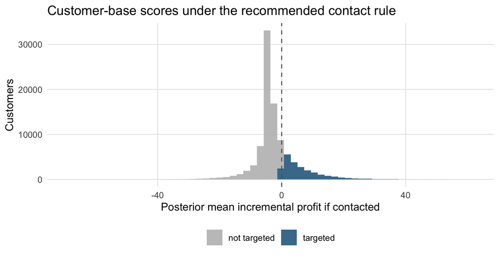

```r
dec_final |>
  mutate(targeted = factor(decision, labels = c("not targeted", "targeted"))) |>
  ggplot(aes(expected_profit, fill = targeted)) +
  geom_histogram(bins = 60, alpha = 0.9, colour = NA) +
  geom_vline(xintercept = 0, linetype = "dashed", colour = "grey40") +
  scale_fill_manual(values = c("not targeted" = "#bdbdbd", "targeted" = "#2b6a8f")) +
  labs(
    x = "Posterior mean incremental profit if contacted",
    y = "Customers",
    fill = NULL,
    title = "Customer-base scores under the recommended contact rule"
  ) +
  theme_minimal(base_size = 11) +
  theme(panel.grid.minor = element_blank(), legend.position = "bottom")
```

[figure not shown]

```r
col_ppos <- "#2ec4b6"
ppos_dens <- density(dec_final$p_positive_ev[dec_final$decision == 1], from = 0, to = 1, n = 512)
ppos_df <- tibble(x = ppos_dens$x, y = ppos_dens$y)
ggplot(ppos_df, aes(x, y)) +
  geom_area_pattern(
    pattern = "stripe",
    fill = NA,
    colour = NA,
    pattern_fill = NA,
    pattern_colour = col_ppos,
    pattern_angle = 45,
    pattern_density = 0.4,
    pattern_spacing = 0.03,
    pattern_linewidth = 0.35
  ) +
  labs(
    x = expression(P(EV > 0 ~ "|" ~ data)),
    y = "Density",
    title = "P(EV > 0) among contacted customers"
  ) +
  theme_minimal(base_size = 11) +
  theme(panel.grid.minor = element_blank())
```

The full length-$N$ recommendation (column `decision`, same row order as `CustomerBase.csv`) is written to `decisions_recommended.csv`.

```r
readr::write_csv(dec_final |> select(decision), decisions_path)
stopifnot(nrow(readr::read_csv(decisions_path, show_col_types = FALSE)) == n_base)
stopifnot(sum(dec_final$decision) <= call_capacity)
cat(sprintf(
  "Wrote %s: %d contacts out of %d (capacity %d).\n",
  decisions_path, sum(dec_final$decision), n_base, call_capacity
))
```

```
Wrote decisions_recommended.csv: 22250 contacts out of 95000 (capacity 23750).
```

# Conclusion

The recommendation itself is summarized in the tables above and stored as `decisions_recommended.csv`.